# Tutorial on Bayesian regression (Pt II)

**Alfredo Garbuno-Inigo**  
Phd student, University of Liverpool  
Institute for Risk and Uncertainty

# Case study: Admittance to university.

```python
print 'Number of records: %s' %(df.shape[0])
print 'Number of features: %s' %(df.shape[1])
```

```
Number of records: 12
Number of features: 5
```

```python
df.head(3)
```

|  | admit | applications | dept | gender | reject |
| --- | --- | --- | --- | --- | --- |
| 0 | 512 | 825 | A | male | 313 |
| 1 | 89 | 108 | A | female | 19 |
| 2 | 353 | 560 | B | male | 207 |

```python
dfsum = df.sum()[['admit','reject','applications']]
dfsum
```

```
admit           1755
reject          2771
applications    4526
dtype: object
```

# Case study: Admittance to university.

```python
print 'Acceptance rate: %s' %(np.ceil(100*(dfsum['admit']+0.0)/dfsum['applications']))
```

```
Acceptance rate: 39.0
```

```python
df.groupby('gender').sum().apply(lambda x: (100*x['admit']+0.)/x['applications'], axis=1)
```

```
gender
female    30.354223
male      44.518766
dtype: float64
```

```python
pd.pivot_table(df, values = 'applications', index = 'dept', columns = 'gender', aggfunc=np.sum)
```

| gender dept | female | male |
| --- | --- | --- |
| A | 108 | 825 |
| B | 25 | 560 |
| C | 593 | 325 |
| D | 375 | 417 |
| E | 393 | 191 |
| F | 341 | 373 |

```python
df.groupby('dept').sum().apply(lambda x: 100.0*x[['admit','reject']]/x['applications'],axis=1)
```

| dept | admit | reject |
| --- | --- | --- |
| A | 64.415863 | 35.584137 |
| B | 63.247863 | 36.752137 |
| C | 35.076253 | 64.923747 |
| D | 33.964646 | 66.035354 |
| E | 25.171233 | 74.828767 |
| F | 6.442577 | 93.557423 |

```python
depts = df.dept.unique()
n_depts = len(depts)
dept_table = dict(zip(depts, range(n_depts)))
dept = df.dept.replace(dept_table).values

dept_table
```

```
{'A': 0, 'B': 1, 'C': 2, 'D': 3, 'E': 4, 'F': 5}
```

```python
gender = df.gender.replace(dict(zip(df.gender.unique(), range(2))))

dict(zip(df.gender.unique(), range(2)))
```

```
{'female': 1, 'male': 0}
```

## Pooled model

$$ \begin{align} A_i & \sim \text{Binomial}(n_i, p_i) \\ \text{logit}(p_i) & = \alpha + \beta \, m_i \\ \beta & \sim \mathcal{N}(0,1) \\ \alpha & \sim \mathcal{N}(0,1) \end{align} $$

```python
with Model() as pooled_model:
    # Priors in regression coefficients
    beta = Normal('beta', 0, sd=1e0, shape=2)
    # Linear model
    theta = beta[0] + beta[1]*gender

    # This just computes the link function, no posterior sampling
    # p = pm.invlogit(theta)

    # To get posterior samples set as a deterministic transformation
    p = pm.Deterministic('p', pm.invlogit(theta))

    y = Binomial('y', n = df.applications, p = p, observed = df.admit)
```

```python
n_samples = 3000
n_opt = 20000
n_warm = 1000

with pooled_model:
    pooled_trace = sample(n_samples, n_init=n_opt, tune=n_warm, njobs = 4)
```

```
Auto-assigning NUTS sampler...
Initializing NUTS using advi+adapt_diag...
Convergence archived at 10000
Interrupted at 10,000 [50%]: Average Loss = 553.29
```

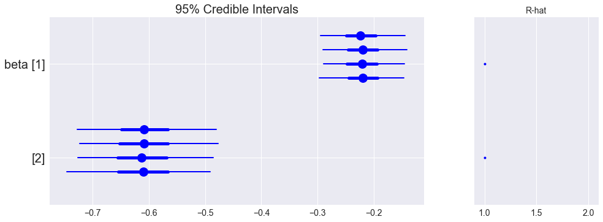

```python
plt.figure(figsize=(15, 5))
forestplot(pooled_trace[n_warm:], varnames = ['beta'], fontsize = 20, linewidth = 5, marker = 'o', markersize = 15, chain_spacing = .15);
```

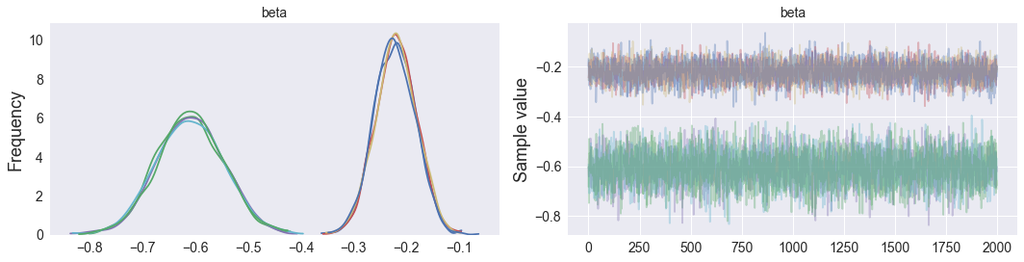

```python
pm.traceplot(pooled_trace[1000:], varnames = ['beta'], figsize=(15, 4));
```

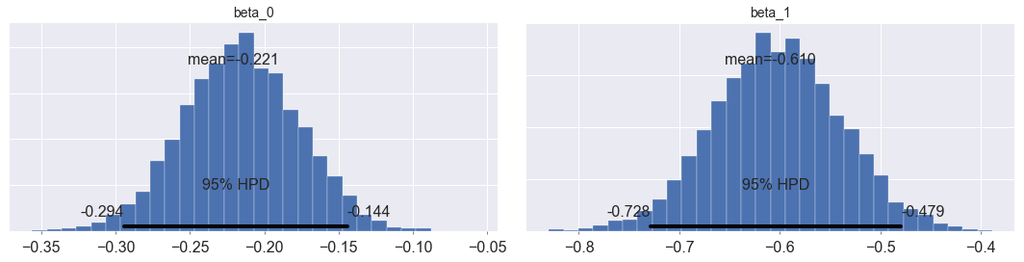

```python
pm.plot_posterior(pooled_trace[1000:], varnames = ['beta'], figsize=(15, 4));
```

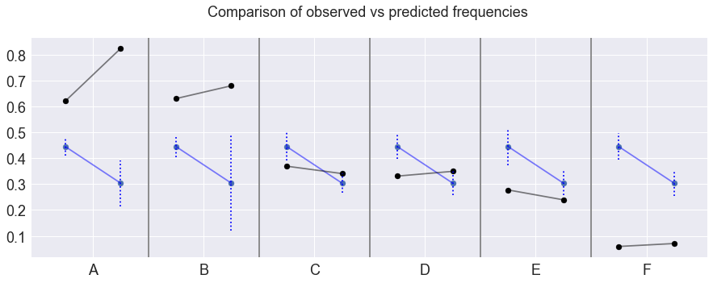

```python
plot_admit(phat, pstd)
```

## Unpooled model

$$ \begin{align} \begin{array}{rlr} A_i & \sim \text{Binomial}(n_i, p_i) \\ \text{logit}(p_i) & = \alpha_{\text{DEPT}[i]} + \beta \, m_i \\ \beta & \sim \mathcal{N}(0,1) \\ \alpha_{\text{DEPT}} & \sim \mathcal{N}(0,1) & \forall \text{ DEPT} \in \{A, \ldots, F\}\\ \end{array} \end{align} $$

```python
with Model() as unpooled_model:
    # Priors in regression coefficients
    beta = Normal('beta', 0, sd=1e0)
    alpha = Normal('alpha', 0, sd = 1e0, shape=n_depts)
    # Linear model
    theta = alpha[dept] + beta * gender

    # To get posterior samples set as a deterministic transformation
    p = pm.Deterministic('p', pm.invlogit(theta))

    y = Binomial('y', n = df.applications, p = p, observed = df.admit)
```

```python
with unpooled_model:
    unpooled_trace = sample(n_samples, n_init=n_opt, tune=n_warm, njobs = 4)
```

```
Auto-assigning NUTS sampler...
Initializing NUTS using advi+adapt_diag...
Convergence archived at 12700
Interrupted at 12,700 [63%]: Average Loss = 227.14
```

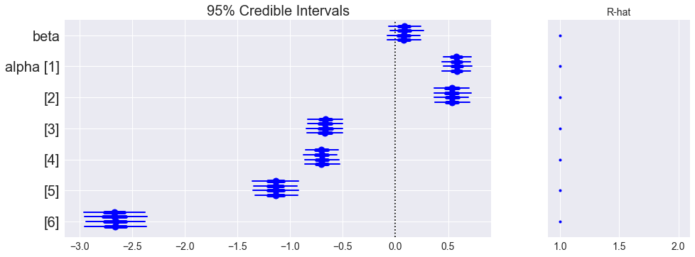

```python
plt.figure(figsize=(15, 5))
forestplot(unpooled_trace[1000:], varnames = ['beta', 'alpha'], fontsize = 20, linewidth = 5, marker = 'o', markersize = 10, chain_spacing = .15);
```

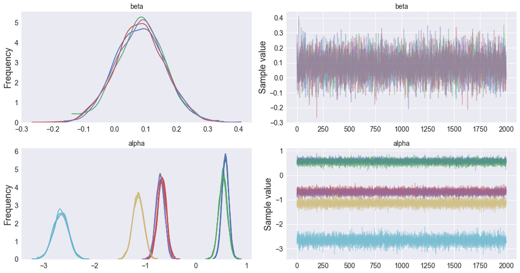

```python
pm.traceplot(unpooled_trace[1000:], varnames = ['beta', 'alpha'], figsize = (15, 8));
```

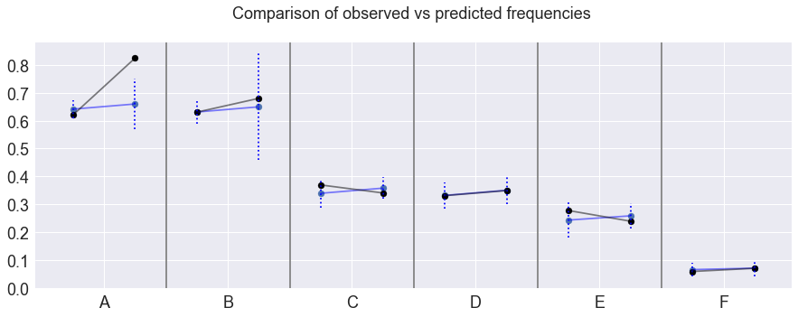

```python
plot_admit(phat_unpooled, pstd_unpooled)
```

## Hierarchical: *varying intercept*

$$ \begin{align} \begin{array}{rlr} A_i & \sim \text{Binomial}(n_i, p_i) \\ \text{logit}(p_i) & = \alpha_{\text{DEPT}[i]} + \beta \, m_i \\ \beta & \sim \mathcal{N}(0,1) \\ \alpha_{\text{DEPT}} & \sim \mathcal{N}(\mu_a,\sigma_a) & \forall \text{ DEPT} \in \{A, \ldots, F\}\\ \mu_a & \sim \mathcal{N}(0,10) \\ \sigma_a & \sim \text{HalfCauchy}(0,2) \end{array} \end{align} $$

```python
with Model() as hierarchical:
    # Priors in highest hierarchy
    mu_a = Normal('mu_a', mu=0., sd=1e1)
    sigma_a = Exponential('sigma_a', 1)

    # Priors in regression coefficients
    beta = Normal('beta', 0, sd=1e0)
    alpha = Normal('alpha', mu_a, sd = sigma_a, shape=n_depts)

    # To get posterior samples set as a deterministic transformation
    theta = alpha[dept] + beta * gender
    p = pm.Deterministic('p', pm.invlogit(theta))
    y = Binomial('y', n = df.applications, p = p, observed = df.admit)
```

```python
with hierarchical:
    hierarchical_trace = sample(n_samples, n_init=n_opt, tune=n_warm, njobs = 4)
```

```
Auto-assigning NUTS sampler...
Initializing NUTS using advi+adapt_diag...
Convergence archived at 12200
Interrupted at 12,200 [61%]: Average Loss = 239.49
```

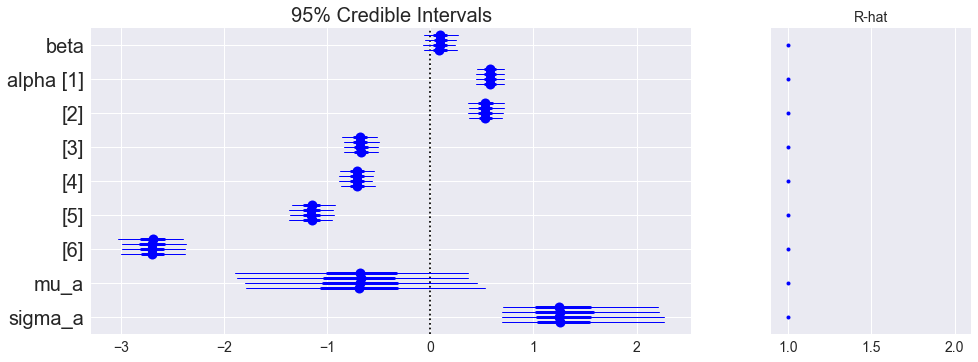

```python
_ = plt.figure(figsize=(15, 5))
forestplot(hierarchical_trace[1000:], varnames = ['beta', 'alpha', 'mu_a', 'sigma_a'], fontsize = 20, linewidth = 3, marker = 'o', markersize = 10, chain_spacing = .15);
```

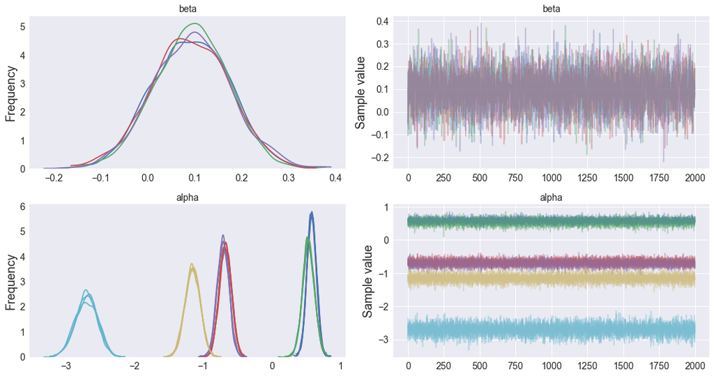

```python
pm.traceplot(hierarchical_trace[1000:], varnames = ['beta', 'alpha'], figsize =(15,8));
```

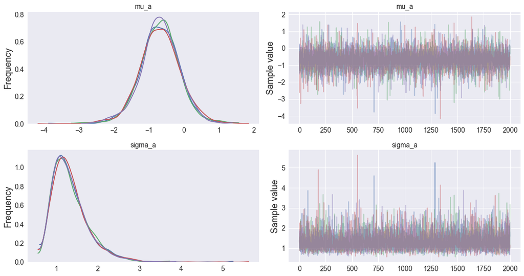

```python
pm.traceplot(hierarchical_trace[1000:], varnames = ['mu_a', 'sigma_a'], figsize = (15,8));
```

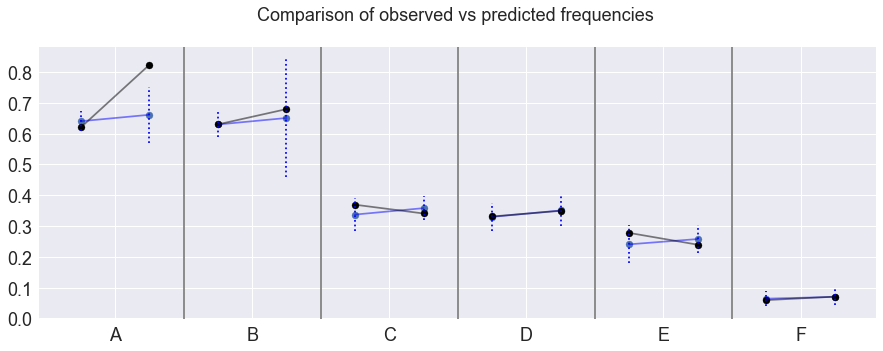

```python
plot_admit(phat_hierarchical, pstd_hierarchical)
```

## Full hierarchical: *Varying slope and intercept*

$$ \begin{align} \begin{array}{rlr} A_i & \sim \text{Binomial}(n_i, p_i) \\ \text{logit}(p_i) & = \alpha_{\text{DEPT}[i]} + \beta_{\text{DEPT}[i]} \, m_i \\ \beta_{\text{DEPT}} & \sim \mathcal{N}(\mu_b,\sigma_b) & \forall \text{ DEPT} \in \{A, \ldots, F\}\\ \alpha_{\text{DEPT}} & \sim \mathcal{N}(\mu_a,\sigma_a) & \forall \text{ DEPT} \in \{A, \ldots, F\}\\ \mu_a & \sim \mathcal{N}(0,10) \\ \mu_b & \sim \mathcal{N}(0,10) \\ \sigma_a & \sim \text{HalfCauchy}(0,2)\\ \sigma_b & \sim \text{HalfCauchy}(0,2) \end{array} \end{align} $$

```python
with Model() as full_hierarchical:
    # Priors in highest hierarchy
    mu_a = Normal('mu_a', mu=0., sd=1e1)
    sigma_a = Exponential('sigma_a', 1)
    mu_b = Normal('mu_b', mu=0., sd=1e1)
    sigma_b = Exponential('sigma_b', 1)

    # Priors in regression coefficients
    beta = Normal('beta', mu_b, sd=sigma_b, shape = n_depts)
    alpha = Normal('alpha', mu_a, sd = sigma_a, shape=n_depts)

    # To get posterior samples set as a deterministic transformation
    theta = alpha[dept] + beta[dept] * gender
    p = pm.Deterministic('p', pm.invlogit(theta))
    y = Binomial('y', n = df.applications, p = p, observed = df.admit)
```

```python
n_samples = 5000
n_warm = 2000

with full_hierarchical:
    full_hierarchical_trace = sample(n_samples, n_init=n_opt, tune=n_warm, njobs = 4)
```

```
Auto-assigning NUTS sampler...
Initializing NUTS using advi+adapt_diag...
Convergence archived at 14300
Interrupted at 14,300 [71%]: Average Loss = 207.41
  % (self._chain_id, n_diverging))
```

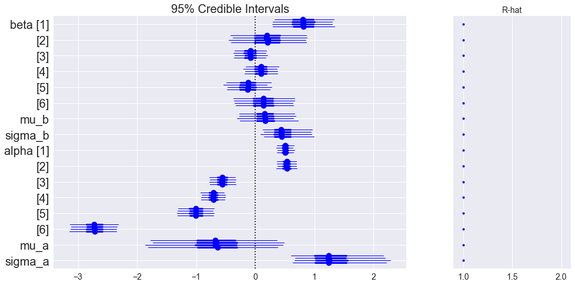

```python
_ = plt.figure(figsize=(15, 7));
forestplot(full_hierarchical_trace[n_warm:], varnames = ['beta', 'mu_b','sigma_b','alpha', 'mu_a', 'sigma_a'], fontsize = 20, linewidth = 3, marker = 'o', markersize = 10, chain_spacing = .15);
```

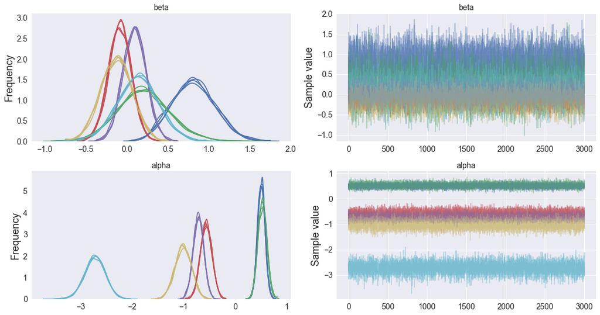

```python
traceplot(full_hierarchical_trace[n_warm:], varnames = ['beta', 'alpha'], figsize=(15, 8));
```

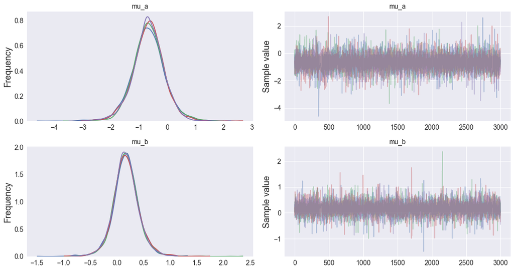

```python
traceplot(full_hierarchical_trace[n_warm:], varnames = ['mu_a', 'mu_b'], figsize=(15, 8));
```

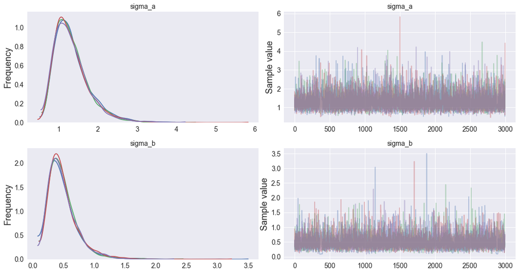

```python
traceplot(full_hierarchical_trace[n_warm:], varnames = ['sigma_a', 'sigma_b'], figsize=(15, 8));
```

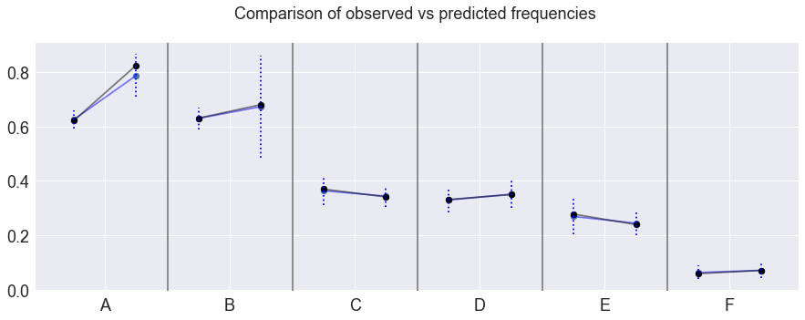

```python
plot_admit(phat_fhierarchical, pstd_fhierarchical)
```

## Model comparison and model averaging

Instead of using likelihoods (never!) compare in terms of a distance between **`in-sample`** and **`out-sample`** accuracy.

Information criteria provides a principled way of measuring distance from the target (*true model*).

- Deviance Information criteria (DIC)
- Watanabe-Akaike Information criteria (WAIC)

### DIC

Is a Bayesian information crierion that uses the posterior samples to **produce a posterior** distribution of the Deviance.

$$ \begin{align} DIC & = \bar{D} + (\bar{D} - \hat{D}) \\ & = \bar{D} + P_D , \end{align} $$

where $P_D$ is interpreted as the *effective* number of parameters (as in the traditional AIC).

It is an Akaike Information Criteria (AIC) that **uses informative priors.**

If parameters are skewed, then it is better not to use it.

```python
traces = [pooled_trace, unpooled_trace, hierarchical_trace, full_hierarchical_trace]
models = [pooled_model, unpooled_model, hierarchical, full_hierarchical]
models_list = ['Pooled '+'.'*23, 'Unpooled '+'.'*21, 'Varying intercept '+'.'*12, 'Varying intercept and slope ..']

for t, m, n in zip(traces, models, models_list):
    print '%s \t : %s' %(n, pm.stats.dic(t,m))
```

```
Pooled ....................... 	 : 860.597995151
Unpooled ..................... 	 : 125.799088181
Varying intercept ............ 	 : 135.994947457
Varying intercept and slope .. 	 : 141.263381938
```

### WAIC

It uses a point-wise estimate of deviance ,*eg* it acknowledges that certaint data-points are harder to predict and have greater uncertainties.

$$ \text{WAIC} = -2 \, ( \, \text{lppd}- P_{\text{WAIC}} \, )$$

where again $P_{\text{WAIC}}$ is interpreted as estimated effective parameters.

```python
pm.stats.waic(full_hierarchical_trace, full_hierarchical)
```

```
WAIC_r(WAIC=91.125548096652693, WAIC_se=4.5298944696436667, p_WAIC=6.8884455064448504)
```

```python
dfwaic = pm.stats.compare(traces, models)
dfwaic
```

|  | WAIC | pWAIC | dWAIC | weight | SE | dSE | warning |
| --- | --- | --- | --- | --- | --- | --- | --- |
| 3 | 91.1255 | 6.88845 | 0 | 0.999617 | 4.52989 | 0 | 0 |
| 1 | 107.913 | 9.04121 | 16.7875 | 0.000226189 | 16.2119 | 13.1834 | 0 |
| 2 | 108.647 | 9.43524 | 17.5212 | 0.00015673 | 15.8554 | 12.7844 | 0 |
| 0 | 989.374 | 112.531 | 898.248 | 8.86553e-196 | 314.498 | 314.64 | 0 |

# Plotting the WAIC values

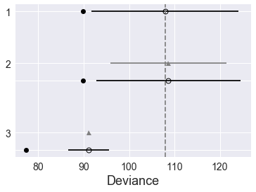

```python
pm.compareplot(dfwaic.loc[range(1,4)]);
plt.figure(figsize=(15, 5));
```

## Another example: tadpole mortality

```python
df.head()
```

|  | density | surv | tank |
| --- | --- | --- | --- |
| 0 | 10 | 9 | 0 |
| 1 | 10 | 10 | 1 |
| 2 | 10 | 7 | 2 |
| 3 | 10 | 10 | 3 |
| 4 | 10 | 9 | 4 |

## Unpooled model

$$ \begin{align} y_i & \sim \text{Binomial}(n_i, p_i) \\ \text{logit}(p_i) & = \alpha_{\text{TANK}(i)} \\ \alpha_{\text{TANK}} &\sim \mathcal{N}(0,70) \end{align} $$

```python
with Model() as tad_unpooled:
    alpha = Normal('alpha', 0, sd = 7e1, shape=n_tanks)

    # To get posterior samples set as a deterministic transformation
    theta = alpha[tank]
    p = pm.Deterministic('p', pm.invlogit(theta))
    y = Binomial('y', n = df.density, p = p, observed = df.surv)
```

```python
with tad_unpooled:
    tad_unpooled_trace = sample(n_samples, n_init=n_opt, tune=n_warm, njobs = 4)
```

```
Auto-assigning NUTS sampler...
Initializing NUTS using advi+adapt_diag...
Finished [100%]: Average Loss = 281.13
  % (self._chain_id, n_diverging))
  % (self._chain_id, n_diverging))
```

## Partially pooled model (*hierarchical*)

$$ \begin{align} y_i & \sim \text{Binomial}(n_i, p_i) \\ \text{logit}(p_i) & = \alpha_{\text{TANK}(i)} \\ \alpha_{\text{TANK}} &\sim \mathcal{N}(\mu_a,\sigma_a) \\ \mu_a & \sim \mathcal{N}(0, 1) \\ \sigma_a & \sim \mathcal{N}(0, 1) \end{align} $$

```python
with Model() as tad_ppooled:
    mu_a = Normal('mu_a', 0, sd = 1)
    sigma_a = Exponential('sigma_a', 1)
    alpha = Normal('alpha', mu_a, sd = sigma_a, shape=n_tanks)

    # To get posterior samples set as a deterministic transformation
    theta = alpha[tank]
    p = pm.Deterministic('p', pm.invlogit(theta))
    y = Binomial('y', n = df.density, p = p, observed = df.surv)
```

```python
with tad_ppooled:
    tad_ppooled_trace = sample(n_samples, n_init=n_opt, tune=n_warm, njobs = 4)
```

```
Auto-assigning NUTS sampler...
Initializing NUTS using advi+adapt_diag...
Convergence archived at 16100
Interrupted at 16,100 [32%]: Average Loss = 203.3
```

## Model comparison and averaging

```python
pm.stats.compare(tad_traces, tad_models)
```

|  | WAIC | pWAIC | dWAIC | weight | SE | dSE | warning |
| --- | --- | --- | --- | --- | --- | --- | --- |
| 1 | 200.591 | 21.1562 | 0 | 0.766398 | 7.11392 | 0 | 0 |
| 0 | 202.967 | 23.6738 | 2.37617 | 0.233602 | 10.6251 | 6.75302 | 0 |

Both have a reduced number of effective parameters by means of a prior.

The unpooled model is using a fixed prior.

The partially pooled model is using a prior learned from data.

## Adaptive regularising priors

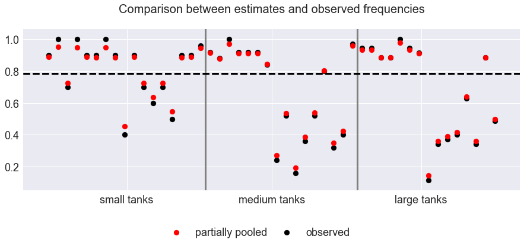

```python
plot_regularize()
```

## Use the hierarchical model to simulate new tanks!

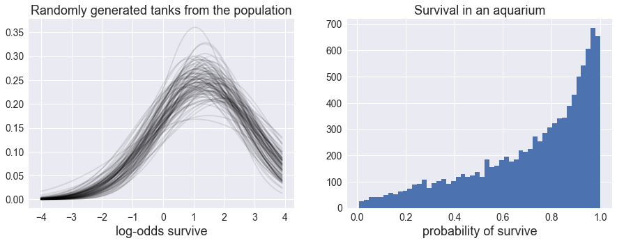

```python
plot_newtanks()
```

## Another insight: Poisson regression and the count of tools

```python
df
```

|  | contact | culture | population | tools |
| --- | --- | --- | --- | --- |
| 0 | low | Malekula | 1100 | 13 |
| 1 | low | Tikopia | 1500 | 22 |
| 2 | low | Santa Cruz | 3600 | 24 |
| 3 | high | Yap | 4791 | 43 |
| 4 | high | Lau Fiji | 7400 | 33 |
| 5 | high | Trobriand | 8000 | 19 |
| 6 | high | Chuuk | 9200 | 40 |
| 7 | low | Manus | 13000 | 28 |
| 8 | high | Tonga | 17500 | 55 |
| 9 | low | Hawaii | 275000 | 71 |

```python
log_pop = np.log(df.population)
contact = df.contact.replace(dict(zip(df.contact.unique(), range(2))))
```

## Full model (linear with interactions)

```python
with Model() as island_m1:
    # Priors
    alpha = Normal('alpha', 0, sd = 1e2)
    beta = Normal('beta', 0, sd = 1e0, shape = 3)
    # Linear Model
    theta = alpha + beta[0] * log_pop + beta[1] * contact + beta[2] * contact * log_pop
    # Likelihood function
    tools = Poisson('tools', mu = np.exp(theta), observed = df.tools)

    island_m1_trace = sample(n_samples, n_init=n_opt, tune=n_warm, njobs = 1)
```

```
Auto-assigning NUTS sampler...
Initializing NUTS using advi+adapt_diag...
Convergence archived at 900
Interrupted at 900 [4%]: Average Loss = 1.6915e+08
```

## Full linear model (no interactions)

```python
with Model() as island_m2:
    # Priors
    alpha = Normal('alpha', 0, sd = 1e2)
    beta = Normal('beta', 0, sd = 1e0, shape = 2)
    # Linear Model
    theta = alpha + beta[0] * log_pop + beta[1] * contact
    # Likelihood function
    tools = Poisson('tools', mu = np.exp(theta), observed = df.tools)

    island_m2_trace = sample(n_samples, n_init=n_opt, tune=n_warm, njobs = 1)
```

```
Auto-assigning NUTS sampler...
Initializing NUTS using advi+adapt_diag...
Convergence archived at 2000
Interrupted at 2,000 [10%]: Average Loss = 7.6638e+06
```

## One predictor

```python
with Model() as island_m3:
    # Priors
    alpha = Normal('alpha', 0, sd = 1e2)
    beta = Normal('beta', 0, sd = 1e0, shape = 1)
    # Linear Model
    theta = alpha + beta[0] * log_pop
    # Likelihood function
    tools = Poisson('tools', mu = np.exp(theta), observed = df.tools)

    island_m3_trace = sample(n_samples, n_init=n_opt, tune=n_warm, njobs = 1)
```

```
Auto-assigning NUTS sampler...
Initializing NUTS using advi+adapt_diag...
Convergence archived at 400
Interrupted at 400 [2%]: Average Loss = 4.4111e+08
```

## The other predictor

```python
with Model() as island_m4:
    # Priors
    alpha = Normal('alpha', 0, sd = 1e2)
    beta = Normal('beta', 0, sd = 1e0, shape = 1)
    # Linear Model
    theta = alpha + beta[0] * contact
    # Likelihood function
    tools = Poisson('tools', mu = np.exp(theta), observed = df.tools)

    island_m4_trace = sample(n_samples, n_init=n_opt, tune=n_warm, njobs = 4)
```

```
Auto-assigning NUTS sampler...
Initializing NUTS using advi+adapt_diag...
Convergence archived at 18100
Interrupted at 18,100 [90%]: Average Loss = 275.95
```

## No predictors

```python
with Model() as island_m5:
    # Priors
    alpha = Normal('alpha', 0, sd = 1e2)
    # Linear Model
    theta = alpha
    # Likelihood function
    tools = Poisson('tools', mu = np.exp(theta), observed = df.tools)

    island_m5_trace = sample(n_samples, n_init=n_opt, tune=n_warm, njobs = 4)
```

```
Auto-assigning NUTS sampler...
Initializing NUTS using advi+adapt_diag...
Convergence archived at 17000
Interrupted at 17,000 [85%]: Average Loss = 328.7
```

## Model averaging

```python
dfwaic = pm.stats.compare(traces, models)
dfwaic
```

|  | WAIC | pWAIC | dWAIC | weight | SE | dSE | warning |
| --- | --- | --- | --- | --- | --- | --- | --- |
| 1 | 79.4119 | 4.40319 | 0 | 0.532108 | 11.0113 | 0 | 0 |
| 0 | 79.9056 | 4.75366 | 0.493785 | 0.415696 | 11.1402 | 1.22117 | 0 |
| 2 | 84.0555 | 3.52364 | 4.64366 | 0.0521966 | 8.87362 | 7.72092 | 0 |
| 4 | 142 | 8.70844 | 62.5884 | 1.36488e-14 | 31.8049 | 32.6961 | 0 |
| 3 | 150.784 | 17.0724 | 71.3726 | 1.68903e-16 | 45.1564 | 44.679 | 0 |

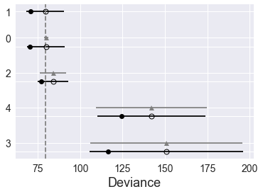

```python
pm.compareplot(dfwaic)
```

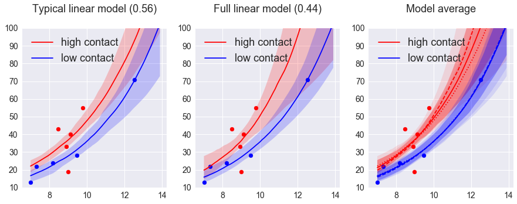

```python
plot_modelavg()
```

## Hierarchical model

```python
with Model() as island_multi:
    # Priors
    sigma_soc = HalfCauchy('sigma_soc', 1)
    alpha = Normal('alpha', 0, sd = 1e1)
    alpha_soc = Normal('alpha_soc', 0, sd = sigma_soc, shape = 10)
    beta = Normal('beta', 0, sd = 1e0)
    # Linear Model
    theta = alpha + alpha_soc[society] + beta * log_pop
    # Likelihood function
    tools = Poisson('tools', mu = np.exp(theta), observed = df.tools)

    island_multi_trace = sample(n_samples, n_init=n_opt, tune=n_warm, njobs = 3)
```

```
Auto-assigning NUTS sampler...
Initializing NUTS using advi+adapt_diag...
Finished [100%]: Average Loss = 105.23
  % (self._chain_id, mean_accept, target_accept))
```

```python
pm.stats.waic(island_multi_trace, island_multi)
```

```
WAIC_r(WAIC=70.351578350103694, WAIC_se=2.6104321464156879, p_WAIC=5.1301502299860342)
```

## Model comparison

```python
dfwaic = pm.stats.compare(traces, models)
dfwaic
```

|  | WAIC | pWAIC | dWAIC | weight | SE | dSE | warning |
| --- | --- | --- | --- | --- | --- | --- | --- |
| 5 | 70.3516 | 5.13015 | 0 | 0.980145 | 2.61043 | 0 | 0 |
| 1 | 79.4119 | 4.40319 | 9.06027 | 0.0105652 | 11.0113 | 9.80526 | 0 |
| 0 | 79.9056 | 4.75366 | 9.55406 | 0.00825378 | 11.1402 | 9.83281 | 0 |
| 2 | 84.0555 | 3.52364 | 13.7039 | 0.00103638 | 8.87362 | 6.79306 | 0 |
| 4 | 142 | 8.70844 | 71.6487 | 2.71003e-16 | 31.8049 | 31.3108 | 0 |
| 3 | 150.784 | 17.0724 | 80.4329 | 3.35363e-18 | 45.1564 | 44.482 | 0 |

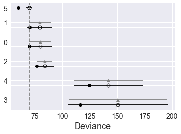

```python
pm.compareplot(dfwaic);
```

## Model output: *overdispersed Poisson model*

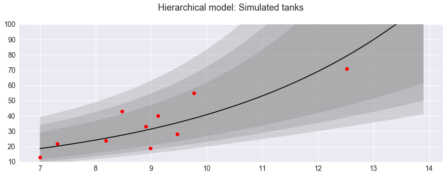

```python
plot_overdisp()
```

### Thanks!

### [Alfredo Garbuno-Inigo](http://agarbuno.github.io/)

### [github](https://github.com/agarbuno)